# Desafio 11

Author

Joaquim Bertoldi Nucci - RA: 277177

```r
cat("Relatório gerado em:", format(Sys.time(), "%d/%m/%Y %H:%M:%S"))
```

Relatório gerado em: 07/10/2025 11:17:37

```r
library(reticulate)
```

```r
reticulate::py_install(c("polars", "matplotlib", "seaborn", "pandas"))
```

```
Using virtual environment "C:/Users/joaqn/OneDrive/Documentos/.virtualenvs/r-reticulate" ...
```

```
+ "C:/Users/joaqn/OneDrive/Documentos/.virtualenvs/r-reticulate/Scripts/python.exe" -m pip install --upgrade --no-user polars matplotlib seaborn pandas
```

```python
import polars as pl
import matplotlib.pyplot as plt
import seaborn as sns
```

1- Utilizando o arquivo renda_adulta.csv e sabendo que ele não possui cabeçalho, faça a importação do banco de dados utilizando os nomes das colunas conforme apresentado acima e na sequência ali indicada. No momento da importação do arquivo, você deve, também, indicar os tipos de cada uma das colunas. Utilize o fato de que o símbolo? representa valores faltantes.

```python
# Definir nomes das colunas
nomes_colunas = [
    "age", "workclass", "fnlwgt", "education", "education_num",
    "marital_status", "occupation", "relationship", "race", "sex",
    "capital_gain", "capital_loss", "hours_per_week",
    "native_country", "income"
]
# Importar o CSV sem cabeçalho
renda = pl.read_csv(
    "dados/renda_adulta.csv",
    has_header=False,
    new_columns=nomes_colunas,
    null_values="?"
)
```

2- Apresente os tipos de cada uma das coluna.

```python
renda.schema
```

```
Schema({'age': Int64, 'workclass': String, 'fnlwgt': Int64, 'education': String, 'education_num': Int64, 'marital_status': String, 'occupation': String, 'relationship': String, 'race': String, 'sex': String, 'capital_gain': Int64, 'capital_loss': Int64, 'hours_per_week': Int64, 'native_country': Str…
```

3- Apresente as dimensões da tabela de dados.

```python
renda.shape
```

```
(32561, 15)
```

4- Quantas pessoas recebem acima de $50.000 e quantas pessoas recebem abaixo deste limiar?

```python
renda.group_by("income").len()
```

shape: (2, 2)

| income str | len u32 |
| --- | --- |
| ">50K" | 7841 |
| "<=50K" | 24720 |

5- Crie um objeto chamado renda_longo, no qual você transforma as colunas capital-gain e capital-loss (formato wide) para formato longo. Os valores destas variáveis devem ser armazenados numa nova coluna chamada Valor e os tipos de valores (gain e loss) devem ser armazenados numa coluna chamada tipo.

```python
renda_longo = renda.unpivot(
    index=[
        "age", "workclass", "fnlwgt", "education", "education_num",
        "marital_status", "occupation", "relationship", "race", "sex",
        "hours_per_week", "native_country", "income"
    ],
    on=["capital_gain", "capital_loss"],
    variable_name="tipo",
    value_name="valor"
)
renda_longo
```

shape: (65_122, 15)

| age i64 | workclass str | fnlwgt i64 | education str | education_num i64 | marital_status str | occupation str | relationship str | race str | sex str | hours_per_week i64 | native_country str | income str | tipo str | valor i64 |
| --- | --- | --- | --- | --- | --- | --- | --- | --- | --- | --- | --- | --- | --- | --- |
| 39 | "State-gov" | 77516 | "Bachelors" | 13 | "Never-married" | "Adm-clerical" | "Not-in-family" | "White" | "Male" | 40 | "United-States" | "<=50K" | "capital_gain" | 2174 |
| 50 | "Self-emp-not-inc" | 83311 | "Bachelors" | 13 | "Married-civ-spouse" | "Exec-managerial" | "Husband" | "White" | "Male" | 13 | "United-States" | "<=50K" | "capital_gain" | 0 |
| 38 | "Private" | 215646 | "HS-grad" | 9 | "Divorced" | "Handlers-cleaners" | "Not-in-family" | "White" | "Male" | 40 | "United-States" | "<=50K" | "capital_gain" | 0 |
| 53 | "Private" | 234721 | "11th" | 7 | "Married-civ-spouse" | "Handlers-cleaners" | "Husband" | "Black" | "Male" | 40 | "United-States" | "<=50K" | "capital_gain" | 0 |
| 28 | "Private" | 338409 | "Bachelors" | 13 | "Married-civ-spouse" | "Prof-specialty" | "Wife" | "Black" | "Female" | 40 | "Cuba" | "<=50K" | "capital_gain" | 0 |
| … | … | … | … | … | … | … | … | … | … | … | … | … | … | … |
| 27 | "Private" | 257302 | "Assoc-acdm" | 12 | "Married-civ-spouse" | "Tech-support" | "Wife" | "White" | "Female" | 38 | "United-States" | "<=50K" | "capital_loss" | 0 |
| 40 | "Private" | 154374 | "HS-grad" | 9 | "Married-civ-spouse" | "Machine-op-inspct" | "Husband" | "White" | "Male" | 40 | "United-States" | ">50K" | "capital_loss" | 0 |
| 58 | "Private" | 151910 | "HS-grad" | 9 | "Widowed" | "Adm-clerical" | "Unmarried" | "White" | "Female" | 40 | "United-States" | "<=50K" | "capital_loss" | 0 |
| 22 | "Private" | 201490 | "HS-grad" | 9 | "Never-married" | "Adm-clerical" | "Own-child" | "White" | "Male" | 20 | "United-States" | "<=50K" | "capital_loss" | 0 |
| 52 | "Self-emp-inc" | 287927 | "HS-grad" | 9 | "Married-civ-spouse" | "Exec-managerial" | "Wife" | "White" | "Female" | 40 | "United-States" | ">50K" | "capital_loss" | 0 |

6- Quais são as médias de horas trabalhadas por classe salarial?

```python
renda.group_by("income").agg(
    pl.col("hours_per_week").mean().alias("media_horas"))
```

shape: (2, 2)

| income str | media_horas f64 |
| --- | --- |
| "<=50K" | 38.84021 |
| ">50K" | 45.473026 |

7- Se cada linha representa uma pessoa, quantas pessoas foram amostradas em cada profissão?

```python
renda.group_by("occupation").len().sort("len", descending=True)
```

shape: (15, 2)

| occupation str | len u32 |
| --- | --- |
| "Prof-specialty" | 4140 |
| "Craft-repair" | 4099 |
| "Exec-managerial" | 4066 |
| "Adm-clerical" | 3770 |
| "Sales" | 3650 |
| … | … |
| "Farming-fishing" | 994 |
| "Tech-support" | 928 |
| "Protective-serv" | 649 |
| "Priv-house-serv" | 149 |
| "Armed-Forces" | 9 |

8- Crie um gráfico de barras que apresente o número médio de horas trabalhadas semanalmente em função do nível salarial.

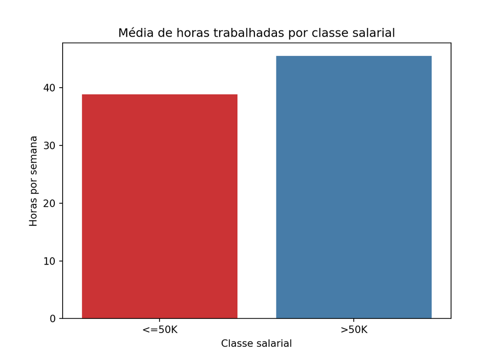

```python
media_horas = renda.group_by("income").agg(
    pl.col("hours_per_week").mean().alias("media_horas")
).to_pandas()

sns.barplot(data=media_horas, x="income", y="media_horas", palette="Set1")
plt.title("Média de horas trabalhadas por classe salarial")
plt.xlabel("Classe salarial")
plt.ylabel("Horas por semana")
plt.show()
```

9- Desafio: existe alguma evidência de discriminação salarial entre gêneros biológicos?

```python
tab = (
    renda.group_by(["sex", "income"])
    .len()
    .with_columns(
        (pl.col("len") / pl.col("len").sum().over("sex")).alias("proporcao")
    )
)

tab
```

shape: (4, 4)

| sex str | income str | len u32 | proporcao f64 |
| --- | --- | --- | --- |
| "Male" | ">50K" | 6662 | 0.305737 |
| "Female" | "<=50K" | 9592 | 0.890539 |
| "Male" | "<=50K" | 15128 | 0.694263 |
| "Female" | ">50K" | 1179 | 0.109461 |